# Data Analysis for Block and Meave (2015, Plant Eco & Div)

## Redundancy analysis

First, load the packages required for the analysis.

```r
library(ade4)
library(vegan)
library(MASS)
library(ellipse)
library(FactoMineR)
```

To load the data, all files must be in the working directory.

```r
structure <- read.csv("str.csv")
env <- read.csv("env.csv")
asp <- read.csv("aspect.csv")
```

I did some modifications to the data. First, I combined all the quantitative variables of the `env` data (i.e., all except the geomorphological unit) with the `asp` data into a single object called `env.quant`. Then, I normalized the data in `env.quant` to allow comparison between variables with very different units. Finally, I added the geomorphological unit column to the normalized quantitative environmental variables to create the data frame `env.ra`, which was used for the redundancy analysis.

```r
env.quant <- cbind(env[,-5],asp)
env.z <- scale(env.quant)
unit <- env[,5]
env.ra <- data.frame(env.z,unit)
```

### Structural data

I did a redundancy analysis on vegetation structure using the environmental data `env.ra` as explanatory variables. I assigned the results to the object `str.rda`.

```r
str.rda <- rda(structure~., env.ra, scale=T)
summary(str.rda)
```

```
##
## Call:
## rda(formula = structure ~ altitude + slope + rock + disturbance +      aspect + unit, data = env.ra, scale = T)
##
## Partitioning of correlations:
##               Inertia Proportion
## Total           4.000      1.000
## Constrained     1.028      0.257
## Unconstrained   2.972      0.743
##
## Eigenvalues, and their contribution to the correlations
##
## Importance of components:
##                         RDA1    RDA2    RDA3    RDA4   PC1    PC2     PC3
## Eigenvalue            0.7970 0.14050 0.08005 0.01048 1.756 0.9250 0.18135
## Proportion Explained  0.1992 0.03512 0.02001 0.00262 0.439 0.2313 0.04534
## Cumulative Proportion 0.1992 0.23436 0.25438 0.25699 0.696 0.9273 0.97263
##                           PC4
## Eigenvalue            0.10948
## Proportion Explained  0.02737
## Cumulative Proportion 1.00000
##
## Accumulated constrained eigenvalues
## Importance of components:
##                         RDA1   RDA2    RDA3    RDA4
## Eigenvalue            0.7970 0.1405 0.08005 0.01048
## Proportion Explained  0.7753 0.1367 0.07787 0.01019
## Cumulative Proportion 0.7753 0.9119 0.98981 1.00000
##
## Scaling 2 for species and site scores
## * Species are scaled proportional to eigenvalues
## * Sites are unscaled: weighted dispersion equal on all dimensions
## * General scaling constant of scores:  3.919476
##
##
## Species scores
##
##        RDA1    RDA2     RDA3     RDA4      PC1      PC2
## ba  -0.9246  0.1831 -0.02910 -0.16244  1.63093 -0.08778
## cov -0.9044 -0.6180  0.07885  0.01387  1.43470  0.38987
```

[output cut: 143 more lines]

```
## unitOC      -0.597827  0.41178 -0.25696  0.27837   0   0
## unitSU       0.006159  0.17893  0.54248 -0.20061   0   0
## unitTE       0.168540 -0.24584 -0.04757  0.21609   0   0
## unitUO      -0.117956  0.23121  0.03658 -0.13147   0   0
##
##
## Centroids for factor constraints
##
##             RDA1    RDA2     RDA3     RDA4 PC1 PC2
## unitCH  0.842845  0.1280 -0.55611 -0.21418   0   0
## unitLO -0.230633 -0.7798  0.24549  0.03045   0   0
## unitOC -0.676414  0.4659 -0.29074  0.31497   0   0
## unitSU  0.006969  0.2024  0.61379 -0.22698   0   0
## unitTE  0.190696 -0.2782 -0.05382  0.24450   0   0
## unitUO -0.133462  0.2616  0.04139 -0.14876   0   0
```

I then got the R squared and the adjusted R squared for this analysis.

```r
(R2 <- RsquareAdj(str.rda)$r.squared)
```

```
## [1] 0.2569949
```

```r
(R2adj <- RsquareAdj(str.rda)$adj.r.squared)
```

```
## [1] 0.1053612
```

To make a triplot with scaling 2.

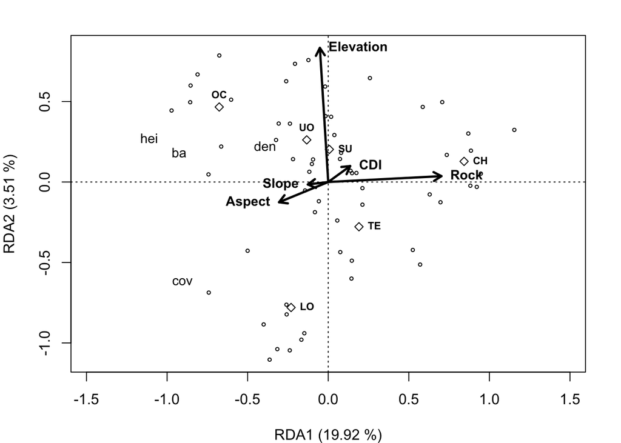

```r
par(mar=c(4,4,2,2))
plot(str.rda, xlab="RDA1 (19.92 %)", ylab="RDA2 (3.51 %)",
     display=c("cn", "lc", "sp"), type="n", xlim=c(-1.3,1.3))
sites.sc <- scores(str.rda, choices=1:2, scaling=2, display="lc")
points(sites.sc, pch=1, cex=0.5)
va.sc <- scores(str.rda, choices=1:2, scaling=2, display="sp")
text(va.sc, row.names(va.sc), cex=0.9)
env.sc <- scores(str.rda, choices=1:2, scaling=2, display="bp")
arrows(0,0, env.sc[1:5,1], env.sc[1:5,2], lty=1, lwd=2.5, length=0.1)
env.names <- c("Elevation", "Slope", "Rock", "CDI", "Aspect")
text(env.sc[c(1,3,4),], env.names[c(1,3,4)], cex=0.9, font=2, pos=4)
text(env.sc[c(2,5),], env.names[c(2,5)], cex=0.9, font=2, pos=2)
unit.names <- c("CH", "LO", "OC", "SU", "TE", "UO")
unit.sc <- scores(str.rda, choices=1:2, scaling=2, display="cn")
points(unit.sc, pch=23)
text(unit.sc[c(1,2,4,5),], unit.names[c(1,2,4,5)], cex=0.7, font=2, pos=4)
text(unit.sc[c(3,6),], unit.names[c(3,6)], cex=0.7, font=2, pos=3)
```

### Composition data

First I loaded the species data. Again, the file `PA_total.csv` must be in the working directory. To reduce the importance of large abundances, I applied the Hellinger transformation to the species data, as recommended by Borcard et al. (2011, Numerical Ecology in R) .

```r
spe <- read.csv("PA_total.csv", sep=",", header=T, row.names=1)
spe.he <- decostand(spe,"hellinger")
```

Then I did a redundancy analysis using all the environmental variables as explanatory variables.

```r
spe.rda <- rda(spe.he~., env.ra)
summary.sperda <- summary(spe.rda)
head(summary.sperda)
```

```
##
## Call:
## rda(formula = spe.he ~ altitude + slope + rock + disturbance +      aspect + unit, data = env.ra)
##
## Partitioning of variance:
##               Inertia Proportion
## Total          0.8593     1.0000
## Constrained    0.2709     0.3153
## Unconstrained  0.5884     0.6847
##
## Eigenvalues, and their contribution to the variance
##
## Importance of components:
##                          RDA1    RDA2    RDA3    RDA4    RDA5    RDA6
## Eigenvalue            0.06795 0.05164 0.04341 0.02369 0.01885 0.01825
## Proportion Explained  0.07908 0.06010 0.05052 0.02757 0.02194 0.02124
## Cumulative Proportion 0.07908 0.13917 0.18970 0.21727 0.23920 0.26044
##                          RDA7    RDA8    RDA9   RDA10     PC1     PC2
## Eigenvalue            0.01308 0.01264 0.01228 0.00910 0.03710 0.02956
## Proportion Explained  0.01522 0.01471 0.01430 0.01059 0.04318 0.03440
## Cumulative Proportion 0.27566 0.29037 0.30467 0.31526 0.35844 0.39283
##                           PC3     PC4     PC5     PC6     PC7     PC8
## Eigenvalue            0.02726 0.02463 0.02326 0.02174 0.02054 0.01957
## Proportion Explained  0.03173 0.02867 0.02708 0.02530 0.02390 0.02278
## Cumulative Proportion 0.42456 0.45323 0.48030 0.50561 0.52951 0.55228
##                           PC9    PC10   PC11    PC12    PC13    PC14
## Eigenvalue            0.01858 0.01787 0.0171 0.01676 0.01637 0.01541
## Proportion Explained  0.02162 0.02080 0.0199 0.01950 0.01905 0.01794
## Cumulative Proportion 0.57390 0.59470 0.6146 0.63410 0.65315 0.67109
##                          PC15    PC16    PC17    PC18    PC19    PC20
## Eigenvalue            0.01469 0.01398 0.01316 0.01289 0.01257 0.01183
## Proportion Explained  0.01710 0.01627 0.01531 0.01500 0.01463 0.01376
## Cumulative Proportion 0.68819 0.70445 0.71976 0.73477 0.74940 0.76316
##                          PC21    PC22    PC23    PC24    PC25     PC26
## Eigenvalue            0.01164 0.01084 0.01070 0.01049 0.01013 0.009514
## Proportion Explained  0.01354 0.01262 0.01245 0.01221 0.01178 0.011070
## Cumulative Proportion 0.77670 0.78932 0.80177 0.81399 0.82577 0.836840
##                           PC27     PC28     PC29     PC30     PC31
## Eigenvalue            0.009407 0.008943 0.008698 0.008482 0.007893
## Proportion Explained  0.010950 0.010410 0.010120 0.009870 0.009190
```

[output cut: 88 more lines]

```
## unitOC      -0.515829 -0.05691  0.7944  0.21470 -0.03435  0.03652
## unitSU       0.051974  0.70402 -0.2385 -0.03111 -0.39614 -0.01947
## unitTE      -0.092466 -0.44377 -0.4847  0.68834  0.13124 -0.03868
## unitUO      -0.099056  0.39376 -0.1009 -0.05393  0.11655 -0.12238
##
##
## Centroids for factor constraints
##
##            RDA1     RDA2    RDA3     RDA4     RDA5     RDA6
## unitCH  0.70194 -0.13731  0.2514 -0.03194  0.06495  0.02806
## unitLO -0.19711 -0.32263 -0.2286 -0.59815  0.07577  0.08288
## unitOC -0.39734 -0.04384  0.6119  0.16538 -0.02646  0.02813
## unitSU  0.04003  0.54230 -0.1837 -0.02396 -0.30514 -0.01500
## unitTE -0.07123 -0.34183 -0.3733  0.53022  0.10109 -0.02980
## unitUO -0.07630  0.30331 -0.0777 -0.04154  0.08978 -0.09427
```

```r
# Get the R^2 and an adjusted R^2
(spR2 <- RsquareAdj(spe.rda)$r.squared)
```

```
## [1] 0.3152582
```

```r
(spR2adj <- RsquareAdj(spe.rda)$adj.r.squared)
```

```
## [1] 0.175515
```

To make a triplot of the RDA on species data with scaling 2.

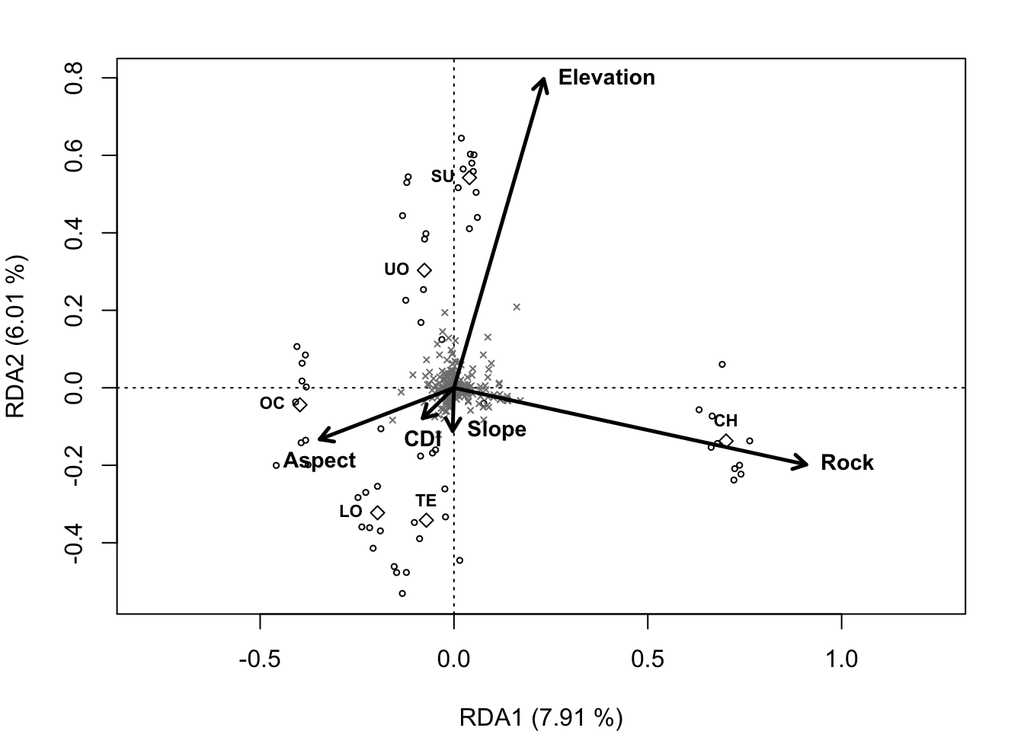

```r
# Make plotting space
par(mar=c(4,4,2,2))
plot(spe.rda, scaling=2, display=c("cn", "lc", "sp"), type="n",
     xlab="RDA1 (7.91 %)", ylab="RDA2 (6.01 %)")

# Plot points for sites
spsites.sc <- scores(spe.rda, choices=1:2, scaling=2, display="lc")
points(spsites.sc, pch=1, cex=0.5)

# Plot points for species
sp.sc <- scores(spe.rda, choices=1:2, scaling=2, display="sp")
points(sp.sc, pch=4, cex=0.5, col="gray50")

# Plot arrows of quantitative explanatory variables and their labels
spenv.sc <- scores(spe.rda, choices=1:2, scaling=2, display="bp")
arrows(0,0, spenv.sc[1:5,1], spenv.sc[1:5,2], lty=1, lwd=2.5, length=0.1, col="black")
env.names <- c("Elevation", "Slope", "Rock", "CDI", "Aspect")
text(spenv.sc[1:3,], env.names[1:3], cex=0.9, font=2, pos=4)
text(spenv.sc[4:5,], env.names[4:5], cex=0.9, font=2, pos=1)

# Plot point for geomorphological unit centroids and their labels
unit.names <- c("CH", "LO", "OC", "SU", "TE", "UO")
spunit.sc <- scores(spe.rda, choices=1:2, scaling=2, display="cn")
points(spunit.sc, pch=23)
text(spunit.sc[c(2,3,4,6),], unit.names[c(2,3,4,6)], cex=0.7, font=2, pos=2)
text(spunit.sc[c(1,5),], unit.names[c(1,5)], cex=0.7, font=2, pos=3)
```

### Plot for the paper

This is the code to make the figure for the paper.

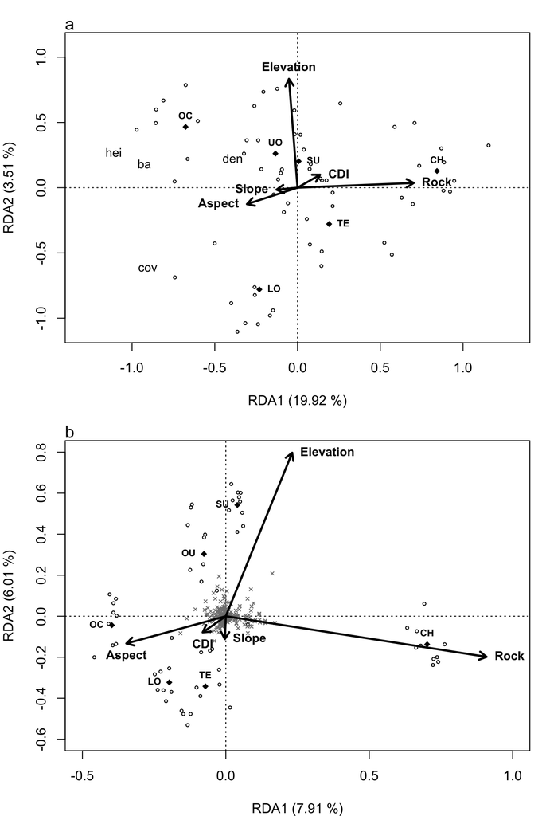

```r
par(mfrow=c(2,1))
# Fig 3a - Structure RDA triplot - Scaling 2 (Correlation triplot)
par(mar=c(4,4,2,1))
plot(1, xlab="RDA1 (19.92 %)", ylab="RDA2 (3.51 %)", type="n",
     xlim=c(-1.3,1.3), ylim=c(-1.1,1.1))
abline(v=0, lty=3); abline(h=0, lty=3); mtext("a", side=3, adj=0, cex=1.25)
sites.sc <- scores(str.rda, choices=1:2, scaling=2, display="lc")
points(sites.sc, pch=1, cex=0.5)
va.sc <- scores(str.rda, choices=1:2, scaling=2, display="sp")
text(va.sc, row.names(va.sc), cex=0.9)
env.sc <- scores(str.rda, choices=1:2, scaling=2, display="bp")
arrows(0,0, env.sc[1:5,1], env.sc[1:5,2], lty=1, lwd=2.5, length=0.1)
env.names <- c("Elevation", "Slope", "Rock", "CDI", "Aspect")
text(env.sc[c(3,4),], env.names[c(3,4)], cex=0.9, font=2, pos=4)
text(env.sc[c(2,5),], env.names[c(2,5)], cex=0.9, font=2, pos=2)
text(env.sc[1,1], env.sc[1,2], env.names[1], cex=0.9, font=2, pos=3)
unit.names <- c("CH", "LO", "OC", "SU", "TE", "UO")
unit.sc <- scores(str.rda, choices=1:2, scaling=2, display="cn")
points(unit.sc, pch=18)
text(unit.sc[c(2,4,5),], unit.names[c(2,4,5)], cex=0.7, font=2, pos=4)
text(unit.sc[c(1,3,6),], unit.names[c(1,3,6)], cex=0.7, font=2, pos=3)

# Fig 3b - Species composition RDA triplot - Scaling 2 (Correlation triplot)
# Make plotting space
par(mar=c(4,4,2,1))
plot(1, type="n", xlim=c(-0.5,1), ylim=c(-0.6,0.8),
     xlab="RDA1 (7.91 %)", ylab="RDA2 (6.01 %)")
abline(v=0, lty=3); abline(h=0, lty=3)
mtext("b", side=3, adj=0, cex=1.25)

# Plot points for sites
spsites.sc <- scores(spe.rda, choices=1:2, scaling=2, display="lc")
points(spsites.sc, pch=1, cex=0.5)

# Plot points for species
sp.sc <- scores(spe.rda, choices=1:2, scaling=2, display="sp")
points(sp.sc, pch=4, cex=0.5, col="gray50")

# Plot arrows of quantitative explanatory variables and their labels
spenv.sc <- scores(spe.rda, choices=1:2, scaling=2, display="bp")
arrows(0,0, spenv.sc[1:5,1], spenv.sc[1:5,2], lty=1, lwd=2.5, length=0.1, col="black")
env.names <- c("Elevation", "Slope", "Rock", "CDI", "Aspect")
text(spenv.sc[1:3,], env.names[1:3], cex=0.9, font=2, pos=4)
text(spenv.sc[4:5,], env.names[4:5], cex=0.9, font=2, pos=1)

# Plot point for geomorphological unit centroids and their labels
unit.names <- c("CH", "LO", "OC", "SU", "TE", "OU")
spunit.sc <- scores(spe.rda, choices=1:2, scaling=2, display="cn")
points(spunit.sc, pch=18)
text(spunit.sc[c(2,3,4,6),], unit.names[c(2,3,4,6)], cex=0.7, font=2, pos=2)
text(spunit.sc[c(1,5),], unit.names[c(1,5)], cex=0.7, font=2, pos=3)
```